# Effect of the 2021 Virginia Minimum Wage Hike on the Employment Level of Food Service Workers in the State

# Results

Average Age: for every 5 years the average age of the population is older, the employment level among Food and beverage retailers decreases by 471 positions, working out to be 94 positions per average year older.

Percent White: for each percentage point higher a county is whiter, the employment among food and beverage retailers level decreases by 10 positions

College Graduation Rate: for every percentage point higher of people with a college degree, food and beverage retailer employment in the county increases by 88 jobs.

State difference: employment among Food and beverage retailers in VA lowers by 664 when compared to NC.

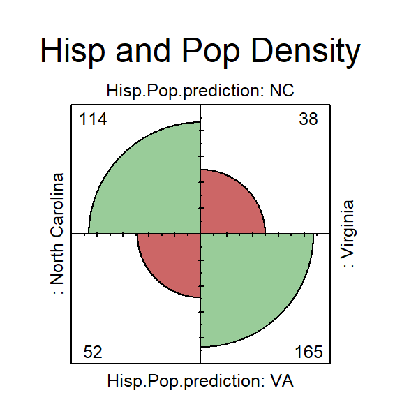

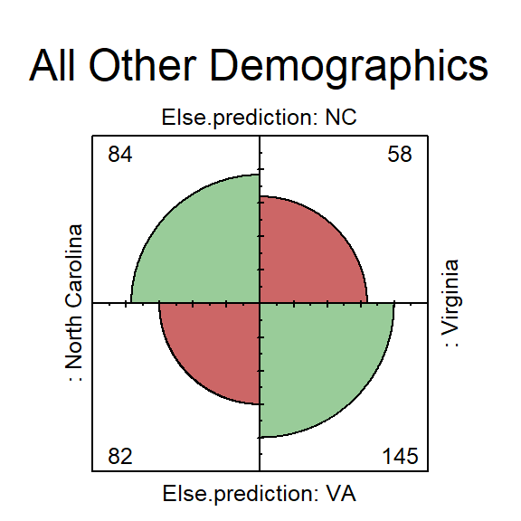

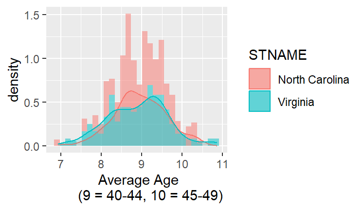

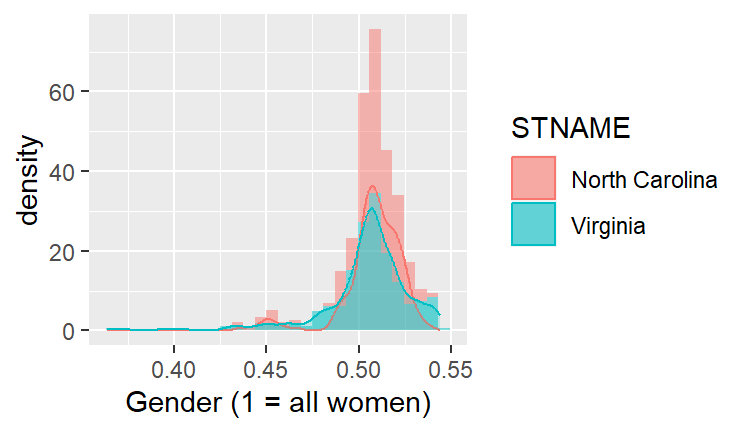

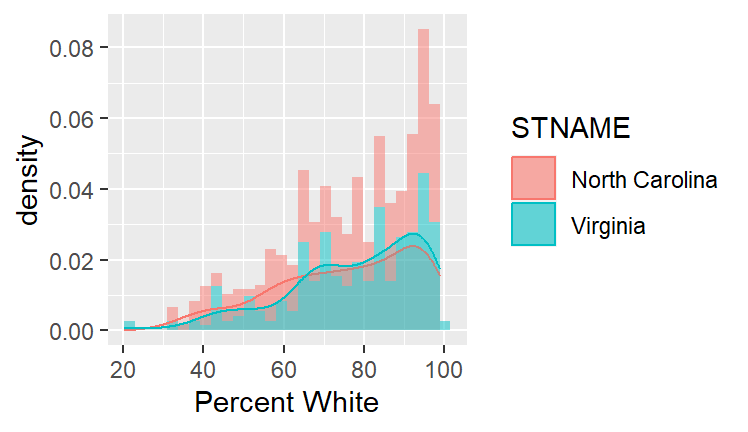

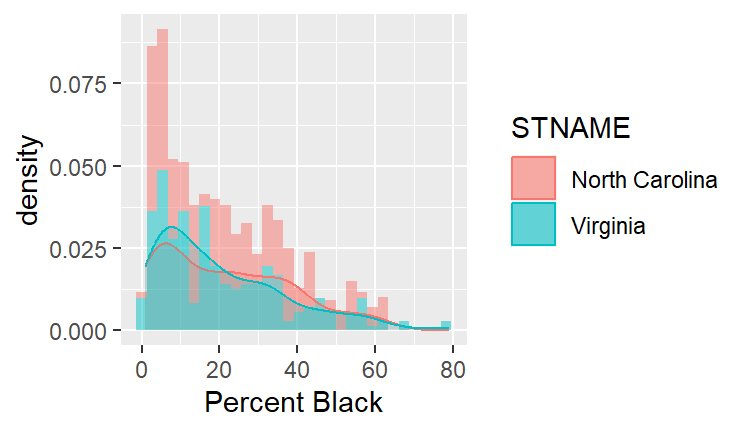

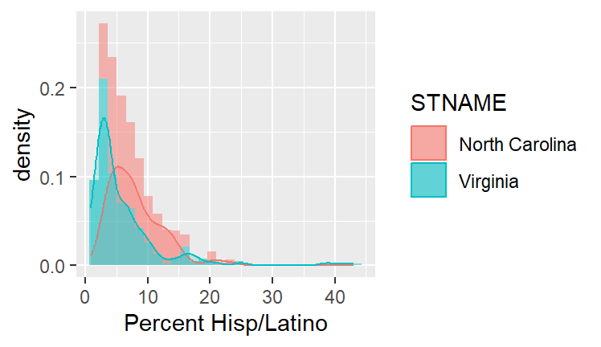

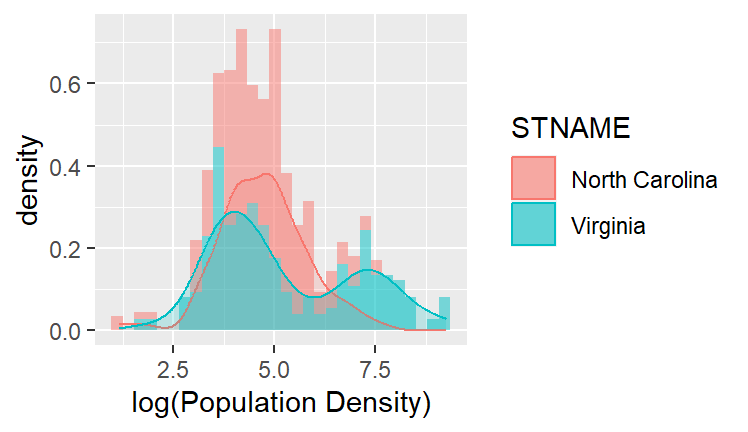

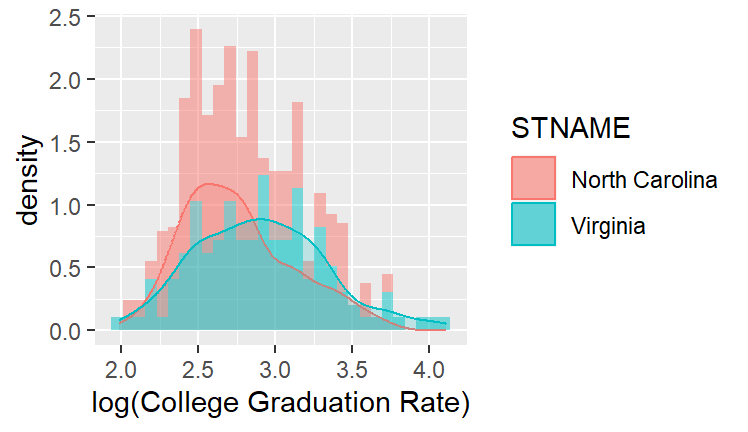

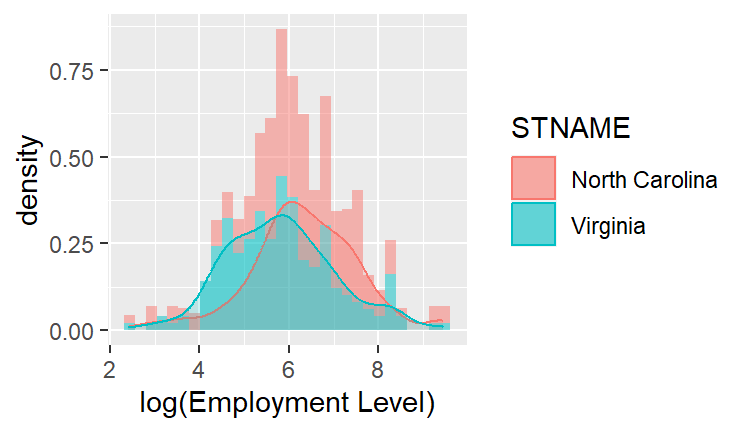

# Discussion

The most fundamental problem with this study is the possibility of a major selection bias. It’s possible that by selecting counties that have the ability to report employment data, I am eliminating the only counties that have had adverse effects on their employment levels from the minimum wage hikes. Another open question is whether North Carolina is similar enough to Virginia for it to be a valid control, even after using variable selection. I did check into a very short lag effect (Q4 2021 to Q1 2022), however its possible it would take longer. Virginia is planning a third hike from $11 an hour to $12 on January 1, 2023 and then two more: $13.50 in 2025 and $15 in 2026. A future study could collect the missing data manually and do another analysis since it appears there will be ample opportunity.

# Sources

Congressional Budget Office , & Alsalam, N., The Effects on Employment and Family Income of Increasing the Federal Minimum Wage (n.d.).

Ferman, B., & Pinto, C. (2019). Inference in differences-in-differences with few treated groups and heteroskedasticity. The Review of Economics and Statistics, 101(3), 452–467. https://doi.org/10.1162/rest_a_00759

U.S. Bureau of Labor Statistics. (n.d.). QCEW data files. U.S. Bureau of Labor Statistics. Retrieved December 7, 2022, from https://www.bls.gov/cew/downloadable-data-files.htm

U.S. Census Bureau. (n.d.). Educational Attainment. Explore census data. Retrieved December 7, 2022, from https://data.census.gov/table?t=Educational%2BAttainment&g=0400000US37%240500000&y=2020&tid=ACSST5Y2020.S1501

US Census Bureau. (2021, October 8). County population by characteristics: 2010-2019. Census.gov. Retrieved December 7, 2022, from https://www.census.gov/data/datasets/time-series/demo/popest/2010s-counties-detail.html

US Census Bureau. (2022, June 30). County population by characteristics: 2020-2021. Census.gov. Retrieved December 7, 2022, from https://www.census.gov/data/datasets/time-series/demo/popest/2020s-counties-detail.html

Virginia Open Data Portal. Tyler Data & Insights. (n.d.). Retrieved December 7, 2022, from https://data.virginia.gov/

https://www.bls.gov/news.release/empsit.t01.htm